```python
%%javascript
IPython.OutputArea.prototype._should_scroll = function(lines) {
    return false;
}
```

# Calculating *Confidence Intervals* for Categorical Data.

# Prequel to Confidence Intervals: Categorical Data

- Before we get into confidence interval, it's important to understand what is **Categorical Data**
- **Categorical Data:** Data that can be divided into groups.
- Examples include: *race, sex, age groups, sports teams, educational level, income groups, preferences, heads or tails*, and the list can go on.
- How can numeric variables like *age groups, and income groups* be categorical?!
- The example variables above are grouped and not discrete. For example, the 'Age Group' may data where the age of each instance is grouped into an age range, such as 1-10, 11-20 and 21-30. Each range is a group, and individuals who fall into a specific bin is counted in that bin. This makes this variable categorical.
- Analysis of categorical data generally involves the use of data tables.
- A common example is a **two-way table**, which represents categorical data by counting the number of observations that fall into each group for two variables. A unique category is in the rows, and the other category is the column, and the actual data inside the table are instances that contain a combination of these groups in each category.
- The total for each category is called the **marginal distribution**.
- Segmented bar graphs are a common graphical tool used to analyze categorical data.
- Analysis of categorical data usualy involves proportions (how much of this group from the entire category).
- Categorical data can be analyzed using single parameters, comparing two parameters, or investigating the potential relationship between two or more categorical variables (such as the two-way table).

# Why Confidence Intervals Matter

- Confidence intervals is a mathematical method to quantify the certainty (or uncertainty) of an estimate. This is important because you rarely ever have the entire population of data to work with, so you need to calculate the probability that your value is within an acceptable range.
- **Confidence Interval:** A range computed using sample statistics to estimate an unknown population parameter with a stated level of confidence
- Confidence intervals is a way of acknowledging uncertainty, and providing a range of potential values rather than a single point estimate. It's a way to be "safe".
- In these cases we can use the sample data that we do have to construct a confidence interval to estimate the population parameter with a stated level of confidence.
- At the center of a confidence interval is the sample statistic, such as a sample mean or sample proportion. AKA point estimate.
- **Sample proportion:** is the parameter that is used when calculating the confidence interval for categorical data.
- The width of the confidence interval is determined by the margin of error.
- The margin of error is the amount that is subtracted from and added to the point estimate to construct the confidence interval.
- This informaiton is visualized in the image below.
- **Margin of Error:** Half of the width of a confidence interval; equal to the multiplier times the standard error
- Confidence intervals are usually expressed as high percentages: *90% or 95%*
- This percentage suggest that the 90% or 95% range contains the sampling distribution of the sample.
- Confidence intervals are similar to frequency tables, histograms, boxplots, and standard errors. These tools help you understand the potential error in your sample estimate.

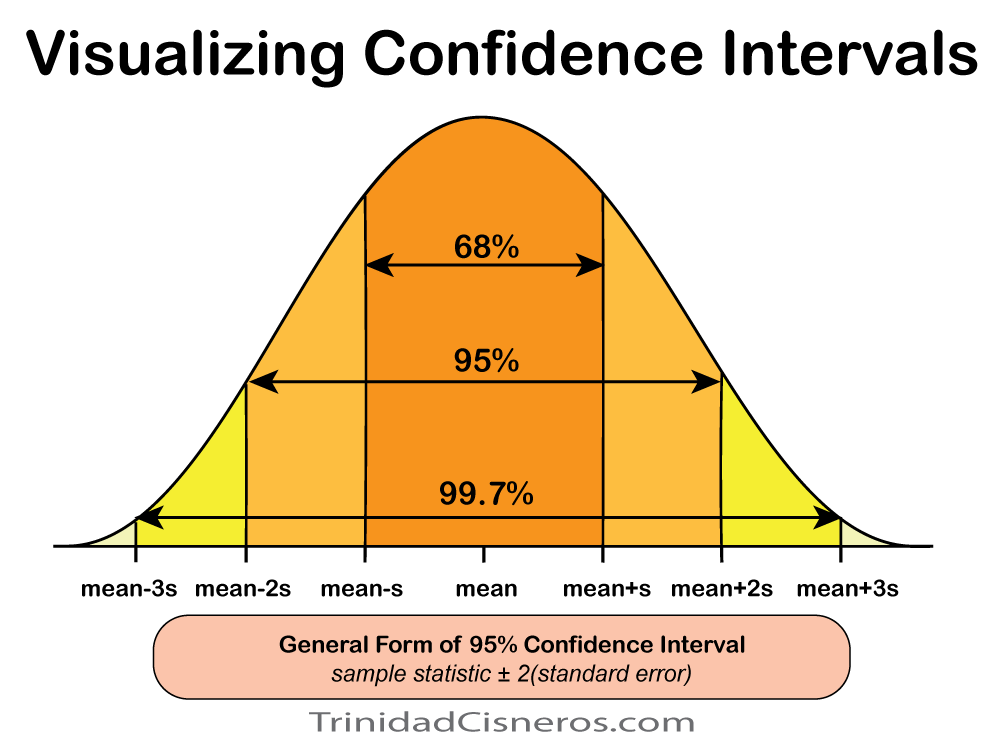

```python
# to load images for this tutorial
from IPython.display import Image
import os
path = os.getcwd()

meme = os.path.join(path, 'confidence_interval.png')
Image(filename=meme)
```

# Post Goals

1. Demonstrate how to calculate the Confidence Intervals and Significance Tests for a Single Proportion
2. Demonstrate how to Compare two Proportions

# Part 1: Calculate the Confidence Intervals and Significance Tests for a Single Proportion

- The formula and common z-score values are depicted below

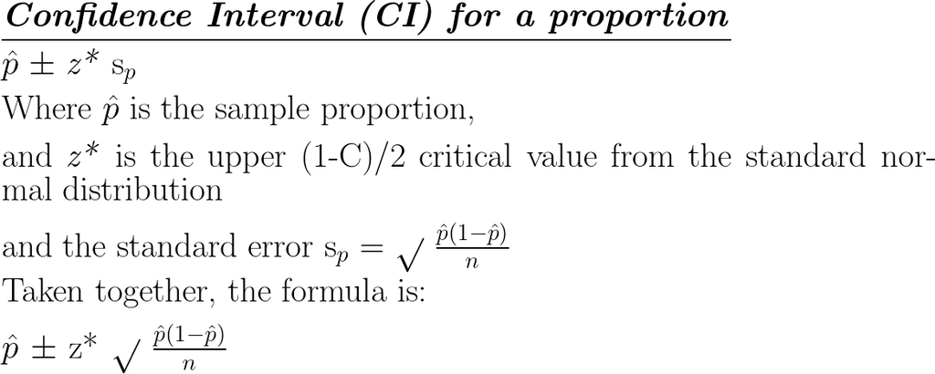

```python
# to load images for this tutorial
from IPython.display import Image
import os
path = os.getcwd()

meme = os.path.join(path, 'ci_proportion.png')
Image(filename=meme)
```

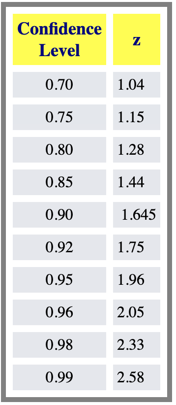

```python
# to load images for this tutorial
from IPython.display import Image
import os
path = os.getcwd()

meme = os.path.join(path, 'zvalueci.png')
Image(filename=meme)
```

# Example

- An online poll [Super Bowl LV Winner](https://racedayct.com/2021/01/racedayct-daily-poll-who-will-win-the-super-bowl/) asked readers to select who they think will win the 2021 Super bowl, the Kansas City Chiefs, or the Tampa Bay Buccanears.
- Kansas City: 70 votes
- Tampa Bay: 93 votes
- **Questions:** What is a 95% confidence interval for the proportion? Is the proportion of those that favor Kansas City Chiefs to win the Super Bowl significantly different from 0.5?
- Python numpy will be used in the calculation

```python
# import python dependencies
import pandas as pd
import numpy as np
```

```python
total_votes = 70+93

# calculate the proportion for each
favor_kansas_proportion = 70 /total_votes
favor_tampa_proportion = 93 /total_votes
print(f'The sample proportion for kansas city winning is {favor_kansas_proportion}')
```

```
The sample proportion for kansas city winning is 0.4294478527607362
```

```python
# find the z-score value from table
z_val = 1.96
```

```python
# calculate the standard error
s_p = np.sqrt((favor_kansas_proportion * (1 - favor_kansas_proportion))/total_votes)
print(f'The standard error for kansas city is: {s_p.round(3)}')
```

```
The standard error for kansas city is: 0.039
```

```python
# put it all together
ci_upper = favor_kansas_proportion + 1.96 * s_p
ci_lower = favor_kansas_proportion - 1.96 * s_p
print(f'The confidence interval for the proportion of pollster that favored Kansas City Chiefs\nLower: {ci_lower.round(3)}\nUpper: {ci_upper.round(3)}')
```

```
The confidence interval for the proportion of pollster that favored Kansas City Chiefs
Lower: 0.353
Upper: 0.505
```

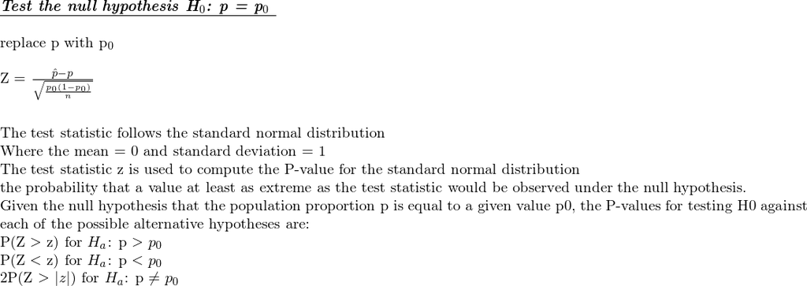

```python
# to load images for this tutorial
from IPython.display import Image
import os
path = os.getcwd()

meme = os.path.join(path, 'hypo_cat.png')
Image(filename=meme)
```

```python
p_0 = 0.5
z_numerator = favor_kansas_proportion - p_0
z_denominator = np.sqrt((p_0 * (1 - p_0))/total_votes)
z = z_numerator/z_denominator
print(f'The test statistic z = {z}')
```

```
The test statistic z = -1.8014990349723012
```

## Get the z value from a table such as [z-table](http://www.z-table.com/)

```python
# the z value for Z at -1.801 is 0.0351
z_val = 0.0351
print(f'The P(Z>{z}) = 1 - P(Z < {z}) = {1 - z_val}')
```

```
The P(Z>-1.8014990349723012) = 1 - P(Z < -1.8014990349723012) = 0.9649
```